# Self-Driving Car Engineer Nanodegree

## Project: Build a Traffic Sign Recognition Classifier

In this notebook, a template is provided for you to implement your functionality in stages, which is required to successfully complete this project. If additional code is required that cannot be included in the notebook, be sure that the Python code is successfully imported and included in your submission if necessary.

> **Note**: Once you have completed all of the code implementations, you need to finalize your work by exporting the iPython Notebook as an HTML document. Before exporting the notebook to html, all of the code cells need to have been run so that reviewers can see the final implementation and output. You can then export the notebook by using the menu above and navigating to \n", "**File -> Download as -> HTML (.html)**. Include the finished document along with this notebook as your submission.

In addition to implementing code, there is a writeup to complete. The writeup should be completed in a separate file, which can be either a markdown file or a pdf document. There is a [write up template](https://github.com/udacity/CarND-Traffic-Sign-Classifier-Project/blob/master/writeup_template.md) that can be used to guide the writing process. Completing the code template and writeup template will cover all of the [rubric points](https://review.udacity.com/#!/rubrics/481/view) for this project.

The [rubric](https://review.udacity.com/#!/rubrics/481/view) contains "Stand Out Suggestions" for enhancing the project beyond the minimum requirements. The stand out suggestions are optional. If you decide to pursue the "stand out suggestions", you can include the code in this Ipython notebook and also discuss the results in the writeup file.

> **Note:** Code and Markdown cells can be executed using the **Shift + Enter** keyboard shortcut. In addition, Markdown cells can be edited by typically double-clicking the cell to enter edit mode.

## Step 0: Load The Data

```python
# Load pickled data
import pickle

# TODO: Fill this in based on where you saved the training and testing data

training_file = './traffic-signs-data/train.p'
validation_file='./traffic-signs-data/valid.p'
testing_file = './traffic-signs-data/test.p'

with open(training_file, mode='rb') as f:
    train = pickle.load(f)
with open(validation_file, mode='rb') as f:
    valid = pickle.load(f)
with open(testing_file, mode='rb') as f:
    test = pickle.load(f)

X_train, y_train = train['features'], train['labels']
X_valid, y_valid = valid['features'], valid['labels']
X_test, y_test = test['features'], test['labels']
```

## Step 1: Dataset Summary & Exploration

The pickled data is a dictionary with 4 key/value pairs:

- `'features'` is a 4D array containing raw pixel data of the traffic sign images, (num examples, width, height, channels).
- `'labels'` is a 1D array containing the label/class id of the traffic sign. The file `signnames.csv` contains id -> name mappings for each id.
- `'sizes'` is a list containing tuples, (width, height) representing the original width and height the image.
- `'coords'` is a list containing tuples, (x1, y1, x2, y2) representing coordinates of a bounding box around the sign in the image. **THESE COORDINATES ASSUME THE ORIGINAL IMAGE. THE PICKLED DATA CONTAINS RESIZED VERSIONS (32 by 32) OF THESE IMAGES**

Complete the basic data summary below. Use python, numpy and/or pandas methods to calculate the data summary rather than hard coding the results. For example, the [pandas shape method](http://pandas.pydata.org/pandas-docs/stable/generated/pandas.DataFrame.shape.html) might be useful for calculating some of the summary results.

### Provide a Basic Summary of the Data Set Using Python, Numpy and/or Pandas

```python
### Replace each question mark with the appropriate value.
### Use python, pandas or numpy methods rather than hard coding the results

# TODO: Number of training examples
n_train = X_train.shape[0]

# TODO: Number of validation examples
n_validation = X_valid.shape[0]

# TODO: Number of testing examples.
n_test = X_test.shape[0]

# TODO: What's the shape of an traffic sign image?
image_shape = X_test.shape[1:]

# TODO: How many unique classes/labels there are in the dataset.
n_classes = len(set(y_train.tolist()))

print("* Number of training examples =", n_train)
print("* The size of the validation = ", n_validation)
print("* Number of testing examples =", n_test)
print("* Image data shape =", image_shape)
print("* Number of classes =", n_classes)
```

```
* Number of training examples = 34799
* The size of the validation =  4410
* Number of testing examples = 12630
* Image data shape = (32, 32, 3)
* Number of classes = 43
```

### Include an exploratory visualization of the dataset

Visualize the German Traffic Signs Dataset using the pickled file(s). This is open ended, suggestions include: plotting traffic sign images, plotting the count of each sign, etc.

The [Matplotlib](http://matplotlib.org/) [examples](http://matplotlib.org/examples/index.html) and [gallery](http://matplotlib.org/gallery.html) pages are a great resource for doing visualizations in Python.

**NOTE:** It's recommended you start with something simple first. If you wish to do more, come back to it after you've completed the rest of the sections. It can be interesting to look at the distribution of classes in the training, validation and test set. Is the distribution the same? Are there more examples of some classes than others?

```python
### Data exploration visualization code goes here.
### Feel free to use as many code cells as needed.
import matplotlib.pyplot as plt
# Visualizations will be shown in the notebook.
%matplotlib inline
```

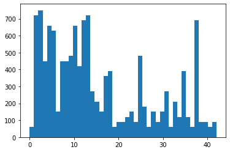

```python
# Histogram of classes in train
hst = plt.hist(y_test, n_classes)
plt.savefig('./writeup_imgs/1_hist.png')
```

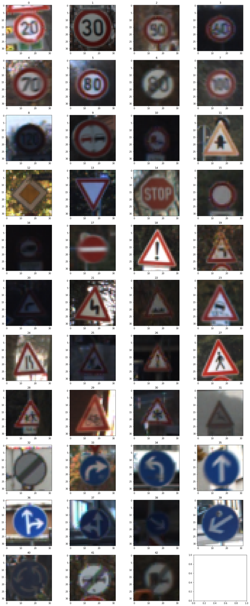

```python
import random
from tqdm import tqdm_notebook as tqdm

fig, ax = plt.subplots(11, 4, figsize=(20, 50))
ax = ax.reshape(-1)
for class_id in tqdm(range(n_classes)):
    sample = random.choice([idx for idx in range(y_train.shape[0]) if y_train[idx] == class_id])
    ax[class_id].imshow(X_train[sample])
    ax[class_id].set_title(str(class_id))
plt.savefig('./writeup_imgs/2_samples.png')
```

## Step 2: Design and Test a Model Architecture

Design and implement a deep learning model that learns to recognize traffic signs. Train and test your model on the [German Traffic Sign Dataset](http://benchmark.ini.rub.de/?section=gtsrb&subsection=dataset).

The LeNet-5 implementation shown in the classroom at the end of the CNN lesson is a solid starting point. You'll have to change the number of classes and possibly the preprocessing, but aside from that it's plug and play!

With the LeNet-5 solution from the lecture, you should expect a validation set accuracy of about 0.89. To meet specifications, the validation set accuracy will need to be at least 0.93. It is possible to get an even higher accuracy, but 0.93 is the minimum for a successful project submission.

There are various aspects to consider when thinking about this problem:

- Neural network architecture (is the network over or underfitting?)
- Play around preprocessing techniques (normalization, rgb to grayscale, etc)
- Number of examples per label (some have more than others).
- Generate fake data.

Here is an example of a [published baseline model on this problem](http://yann.lecun.com/exdb/publis/pdf/sermanet-ijcnn-11.pdf). It's not required to be familiar with the approach used in the paper but, it's good practice to try to read papers like these.

### Pre-process the Data Set (normalization, grayscale, etc.)

Minimally, the image data should be normalized so that the data has mean zero and equal variance. For image data, `(pixel - 128)/ 128` is a quick way to approximately normalize the data and can be used in this project.

Other pre-processing steps are optional. You can try different techniques to see if it improves performance.

Use the code cell (or multiple code cells, if necessary) to implement the first step of your project.

```python
### Preprocess the data here. It is required to normalize the data. Other preprocessing steps could include
### converting to grayscale, etc.
### Feel free to use as many code cells as needed.
import numpy as np
import scipy.ndimage as ndi
import cv2

class Dataset:

    def __init__(self, images, normalize = None, augment = True):
        self.images = images
        self.X = [self._get_features_(images[i]) for i in range(images.shape[0])]
        self.X = np.stack(self.X)
        if normalize:
            self.normalize = normalize
        else:
            self.normalize = (np.mean(self.X, axis=0), np.std(self.X, axis=0) + 0.001)
        self.X = (self.X - self.normalize[0]) / self.normalize[1]
        self.augment = augment

    def __len__(self):
        return self.X.shape[0]

    def __getitem__(self, item):
        return self._augment_(self.X[item])
        #return self.X[item]

    def get_image(self, idx):
        return self.images[idx]

    def _augment_(self, img):
        if not self.augment:
            return img
        if len(img.shape) == 4:
            # batch mode
            for i in range(img.shape[0]):
                img[i] = self._augment_(img[i])
            return img
        else:
            # rotation
            img = ndi.rotate(img, axes=(0, 1), angle=random.uniform(-5, 5), reshape=False, order=2)
            # shift
            dx = random.uniform(-5, 5)
            dy = random.uniform(-5, 5)
            img = ndi.shift(img, shift=(dx, dy, 0))
            return img

    def _get_features_(self, img):
        img = self._fix_dark(img)

        # convert to float
        img = img.copy().astype('float32')
        img = img / 255.

        # normalize color

        # add Luv color space
        lab = cv2.cvtColor(img, cv2.COLOR_RGB2LAB)
        img = np.concatenate([img, lab], axis=2)

        return img

    def _fix_dark(self, img):
        lab = cv2.cvtColor(img, cv2.COLOR_RGB2LAB)
        lab_planes = cv2.split(lab)
        clahe = cv2.createCLAHE(clipLimit=2.0,tileGridSize=(4,4))
        lab_planes[0] = clahe.apply(lab_planes[0])
        lab = cv2.merge(lab_planes)
        img = cv2.cvtColor(lab, cv2.COLOR_LAB2RGB)
        return img

train = Dataset(X_train)
test = Dataset(X_test, train.normalize, False)
valid = Dataset(X_valid, train.normalize, False)
```

```
Clipping input data to the valid range for imshow with RGB data ([0..1] for floats or [0..255] for integers).
```

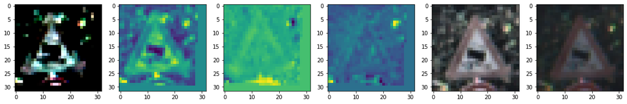

```python
fig, ax = plt.subplots(1, 6, figsize=(20,3))

idx = 2000
x = train[idx]
ax[0].imshow(x[:, :, :3])
ax[1].imshow(x[:, :, 3])
ax[2].imshow(x[:, :, 4])
ax[3].imshow(x[:, :, 5])
ax[4].imshow(train._fix_dark(train.get_image(idx)))
ax[5].imshow(train.get_image(idx))
fig.savefig('./writeup_imgs/3_dataset.png')
```

### Model Architecture

```python
### Define your architecture here.
### Feel free to use as many code cells as needed.
import tensorflow as tf
from tensorflow.contrib.layers import flatten
import numpy


def _conv_layer(x, shape, name):
    sigma = 1 / numpy.sqrt((shape[0]*shape[1]*shape[2]))
    conv_w = tf.Variable(tf.random_uniform(shape, -sigma, sigma), name = name + '_w')
    conv_b = tf.Variable(tf.random_uniform([shape[-1]], -sigma, sigma), name = name + '_b')
    conv = tf.nn.conv2d(x, conv_w, strides=1, padding='SAME') + conv_b
    conv = tf.nn.relu(conv)
    conv = tf.nn.max_pool2d(conv, ksize=2, strides=2, padding='VALID')
    return conv

def lenet(x, n_classes, dropout):

    conv1 = _conv_layer(x, (3,3,6,32), 'conv1')
    conv2 = _conv_layer(conv1, (3,3,32,64), name='conv2')
    conv3 = _conv_layer(conv2, (3,3,64,128), name='conv3')
    conv4 = _conv_layer(conv3, (3,3,128,512), name='conv4')
    maxpool = tf.nn.max_pool2d(conv4, ksize=2, strides=2, padding='VALID')

    fc0 = flatten(maxpool)
    fc0 = tf.nn.dropout(fc0, rate=dropout)

    sigma = 1 / numpy.sqrt(512)
    fc1_w = tf.Variable(tf.random_uniform((512, 256), -sigma, sigma))
    fc1_b = tf.Variable(tf.random_uniform((256,), -sigma, sigma))
    fc1 = tf.matmul(fc0, fc1_w) + fc1_b
    fc1 = tf.nn.relu(fc1)
    fc1 = tf.nn.dropout(fc1, rate=dropout)

    sigma = 1 / numpy.sqrt(256)
    fc2_w = tf.Variable(tf.random_uniform((256, n_classes), -sigma, sigma))
    fc2_b = tf.Variable(tf.random_uniform((n_classes,), -sigma, sigma))
    fc2 = tf.matmul(fc1, fc2_w) + fc2_b

    return fc2
```

### Train, Validate and Test the Model

A validation set can be used to assess how well the model is performing. A low accuracy on the training and validation sets imply underfitting. A high accuracy on the training set but low accuracy on the validation set implies overfitting.

```python
x = tf.placeholder(tf.float32, (None, 32, 32, 6))
y = tf.placeholder(tf.int32, (None, ))
dropout = tf.placeholder(tf.float32, shape=[], name='dropout_rate')
learning_rate = tf.placeholder(tf.float32, shape=[], name='learning_rate')

logits = lenet(x, n_classes, dropout)
y_one_hot = tf.one_hot(y, n_classes)
cross_entropy = tf.nn.softmax_cross_entropy_with_logits_v2(y_one_hot, logits)
loss_operation = tf.reduce_mean(cross_entropy)
optimizer = tf.train.MomentumOptimizer(learning_rate=learning_rate, momentum=0.99, use_nesterov=True)
training = optimizer.minimize(loss_operation)
```

[output not shown]

```python
correct_answers = tf.equal(tf.argmax(logits, 1), tf.argmax(y_one_hot, 1))
accuracy_operation = tf.reduce_mean(tf.cast(correct_answers, tf.float32))

def evaluate(X_data, y_data):
    _EVAL_BATCH = 128
    total_samples = len(X_data)
    total_accuracy = 0.
    total_loss = 0.
    sess = tf.get_default_session()
    for offset in tqdm(range(0, total_samples, _EVAL_BATCH), total=total_samples/_EVAL_BATCH, desc='eval'):
        batch_x = X_data[offset:offset+_EVAL_BATCH]
        batch_y = y_data[offset:offset+_EVAL_BATCH]
        batch_accuracy, batch_loss = sess.run([accuracy_operation, loss_operation],
                                              feed_dict={x: batch_x, y: batch_y, dropout:0})
        total_accuracy += batch_accuracy * len(batch_x)
        total_loss += batch_loss
    return {'acc': total_accuracy / total_samples, 'loss': total_loss}
```

```python
from sklearn.utils import shuffle
import pickle

_TRAIN_BATCH = 64

metrics = []
saver = tf.train.Saver(max_to_keep=100)
with tf.Session() as sess:
    sess.run(tf.global_variables_initializer())
    total_samples = len(train)
    for epoch in range(50):
        lr = 0.001
        train.augment = False
        if epoch > 5:
            train.augment = True
        if epoch > 20:
            lr = 0.0001
        _x_train = [x for x in tqdm(train, desc='augmentation')]
        _x_train, _y_train = shuffle(_x_train, y_train)
        train_total_loss = 0
        for offset in tqdm(range(0, total_samples, _TRAIN_BATCH), total=total_samples/_TRAIN_BATCH, desc=f'epoch {epoch}'):
            batch_x = _x_train[offset:offset+_TRAIN_BATCH]
            batch_y = _y_train[offset:offset+_TRAIN_BATCH]
            batch_loss, _ = sess.run([loss_operation, training],
                                  feed_dict={x: batch_x, y: batch_y, dropout:0.3, learning_rate: lr})
            train_total_loss += batch_loss
        m = evaluate(valid, y_valid)
        m['train_loss'] = train_total_loss
        print(m)
        metrics.append(m)
        saver.save(sess, './model/sign_model', global_step=epoch)

with open('./metrics.pkl', 'wb') as f:
    pickle.dump(metrics, f)
```

```
{'acc': 0.2210884353961128, 'loss': 97.46434736251831, 'train_loss': 1828.1458020210266}
```

```
{'acc': 0.5639455782312925, 'loss': 49.16544472426176, 'train_loss': 992.6506700515747}
```

```
{'acc': 0.8206349206889838, 'loss': 21.427328341640532, 'train_loss': 406.8679751753807}
```

```
{'acc': 0.8893424035199916, 'loss': 13.998069244378712, 'train_loss': 126.02120780572295}
```

```
{'acc': 0.9188208617050361, 'loss': 10.871877994504757, 'train_loss': 56.47565410193056}
```

```
{'acc': 0.9253968256671412, 'loss': 9.15714987469255, 'train_loss': 36.2942763378378}
```

```
{'acc': 0.9258503398927701, 'loss': 9.625539104657946, 'train_loss': 316.2349384613335}
```

```
{'acc': 0.9394557826373042, 'loss': 8.628306309576146, 'train_loss': 93.74374521709979}
```

```
{'acc': 0.943764172200443, 'loss': 7.8895203638003295, 'train_loss': 60.374097471125424}
```

```
{'acc': 0.9390022678980752, 'loss': 8.845210301271436, 'train_loss': 49.70119528006762}
```

```
{'acc': 0.9455782311032959, 'loss': 9.206770389710073, 'train_loss': 39.25718820816837}
```

```
{'acc': 0.9517006805424247, 'loss': 7.3265627652726835, 'train_loss': 31.63493437739089}
```

```
{'acc': 0.9489795918367347, 'loss': 6.5638535102395394, 'train_loss': 28.269255702733062}
```

```
{'acc': 0.9437641720923167, 'loss': 8.526968102276953, 'train_loss': 23.613419393543154}
```

```
{'acc': 0.951927437668755, 'loss': 6.256065528441582, 'train_loss': 18.12360526723205}
```

```
{'acc': 0.9612244900932658, 'loss': 5.8932993844599935, 'train_loss': 17.81115926973871}
```

```
{'acc': 0.9562358279617466, 'loss': 6.547260832459163, 'train_loss': 16.249925611418803}
```

```
{'acc': 0.9578231295220165, 'loss': 6.536772526760842, 'train_loss': 16.835284277964092}
```

```
{'acc': 0.9530612245168275, 'loss': 7.202544878238001, 'train_loss': 13.593214786233148}
```

[output not shown]

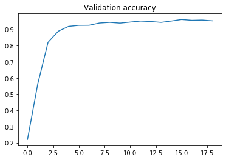

```python
plt.plot([r['acc'] for r in metrics])
plt.title('Validation accuracy')
plt.savefig('./writeup_imgs/4_valid_during_train.png')
```

```python
# Run on test set
with tf.Session() as sess:
    saver.restore(sess, './model/sign_model-15')
    print('Evaluate validation')
    print(evaluate(valid, y_valid))
    print('Evaluate testset')
    print(evaluate(test, y_test))
    print('Evaluate trainset')
    print(evaluate(train, y_train))
```

```
INFO:tensorflow:Restoring parameters from ./model/sign_model-15
Evaluate validation
```

```
{'acc': 0.9612244900932658, 'loss': 5.8932993844599935}
Evaluate testset
```

```
{'acc': 0.957561361685879, 'loss': 17.453744389116764}
Evaluate trainset
```

```
{'acc': 0.9955458490357783, 'loss': 3.8971116529512053}
```

# Step 3: Test a Model on New Images

To give yourself more insight into how your model is working, download at least five pictures of German traffic signs from the web and use your model to predict the traffic sign type.

You may find signnames.csv useful as it contains mappings from the class id (integer) to the actual sign name.

### Load and Output the Images

```python
### Load the images and plot them here.
### Feel free to use as many code cells as needed.
def get_sing_sample(cls_idx):
    good = [i for i,c in enumerate(y_train) if c == cls_idx]
    sample = random.choice(good)
    return X_train[sample]
```

[figure not shown]

```python
img1 = cv2.imread('./test_images/1.jpg')
img1 = cv2.cvtColor(img1, cv2.COLOR_BGR2RGB)
img1 = img1[400:850, 500:950]
img1 = cv2.resize(img1, (32, 32), interpolation=cv2.INTER_AREA)

fig, ax = plt.subplots(1, 2, figsize=(10,5))
ax[0].imshow(img1)
ax[1].imshow(get_sing_sample(17))
```

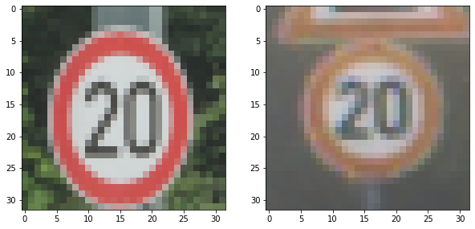

```python
img2 = cv2.imread('./test_images/2.jpg')
img2 = cv2.cvtColor(img2, cv2.COLOR_BGR2RGB)
img2 = img2[200:600, 200:700]
img2 = cv2.resize(img2, (32, 32), interpolation=cv2.INTER_AREA)
fig, ax = plt.subplots(1, 2, figsize=(10,5))
ax[0].imshow(img2)
ax[1].imshow(get_sing_sample(0))
```

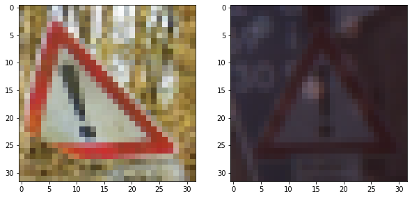

```python
img3 = cv2.imread('./test_images/3.jpg')
img3 = cv2.cvtColor(img3, cv2.COLOR_BGR2RGB)
img3 = img3[250:550, 1200:1500]
img3 = cv2.resize(img3, (32, 32), interpolation=cv2.INTER_AREA)
fig, ax = plt.subplots(1, 2, figsize=(10,5))
ax[0].imshow(img3)
ax[1].imshow(get_sing_sample(18))
```

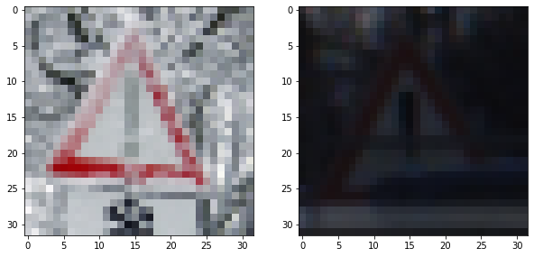

```python
img4 = cv2.imread('./test_images/4.jpg')
img4 = cv2.cvtColor(img4, cv2.COLOR_BGR2RGB)
img4 = img4[0:400, 150:550]
img4 = cv2.resize(img4, (32, 32), interpolation=cv2.INTER_AREA)
fig, ax = plt.subplots(1, 2, figsize=(10,5))
ax[0].imshow(img4)
ax[1].imshow(get_sing_sample(18))
```

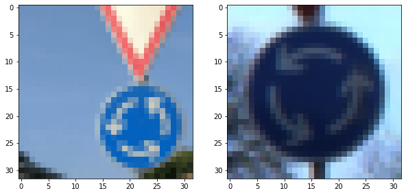

```python
img5 = cv2.imread('./test_images/5.png')
img5 = cv2.cvtColor(img5, cv2.COLOR_BGR2RGB)
img5 = img5[80:155, 100:175]
img5 = cv2.resize(img5, (32, 32), interpolation=cv2.INTER_AREA)
fig, ax = plt.subplots(1, 2, figsize=(10,5))
ax[0].imshow(img5)
ax[1].imshow(get_sing_sample(40))
```

```python
with open('./signnames.csv', 'rt') as f:
    lines = [l.split(',') for l in f.readlines()[1:]]
    id2name = {int(l[0]): l[1][:-1] for l in lines}
```

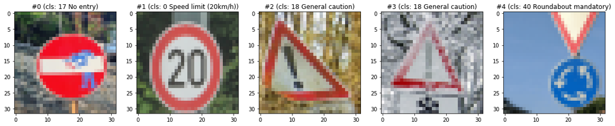

```python
X_web = np.stack([img1, img2, img3, img4, img5])
y_web = np.array([17, 0, 18, 18, 40])
web = Dataset(X_web, train.normalize, False)

fig, ax = plt.subplots(1, 5, figsize=(20,5))
for i in range(5):
    ax[i].imshow(X_web[i])
    ax[i].set_title(f'#{i} (cls: {y_web[i]} {id2name[y_web[i]]})')
fig.savefig('./writeup_imgs/5_web_signs.png')
```

### Predict the Sign Type for Each Image

```python
### Run the predictions here and use the model to output the prediction for each image.
### Make sure to pre-process the images with the same pre-processing pipeline used earlier.
### Feel free to use as many code cells as needed.
with tf.Session() as sess:
    saver.restore(sess, './model/sign_model-15')
    predicts = sess.run(logits, feed_dict={x: web, y: y_web, dropout:0})
```

```
INFO:tensorflow:Restoring parameters from ./model/sign_model-15
```

### Analyze Performance

```python
### Calculate the accuracy for these 5 new images.
### For example, if the model predicted 1 out of 5 signs correctly, it's 20% accurate on these new images.
accuracy = np.mean(np.equal(y_web, np.argmax(predicts, axis=1)))
print('Accuracy:', accuracy*100, '%')
```

```
Accuracy: 80.0 %
```

```
90 sings Roundabout mandatory in test set
INFO:tensorflow:Restoring parameters from ./model/sign_model-15
Incorrectly recognized signs 2
```

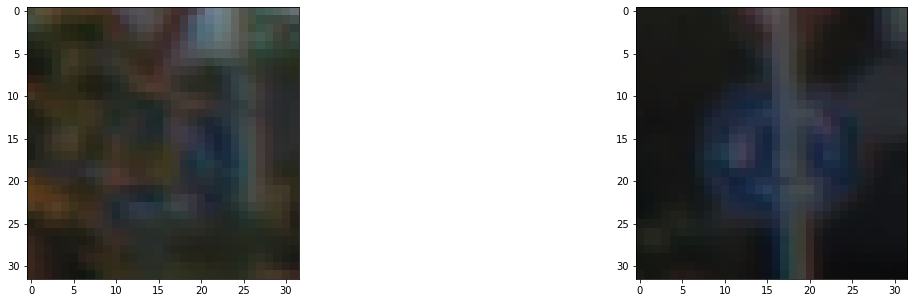

```python
idx_40 = [i for i,c in enumerate(y_test) if c == 40]
print(f'{len(idx_40)} sings {id2name[40]} in test set')
X_40 = np.stack([X_test[i] for i in idx_40])
y_40 = np.array([40] * len(idx_40))
x_40 = Dataset(X_40, train.normalize, False)
with tf.Session() as sess:
    saver.restore(sess, './model/sign_model-15')
    predicts_40 = sess.run(logits, feed_dict={x: x_40, y: y_40, dropout:0})

wrong = np.not_equal(y_40, np.argmax(predicts_40, axis=1))
print(f'Incorrectly recognized signs {np.sum(wrong)}')
cnt = 0
fig, ax = plt.subplots(1, np.sum(wrong), figsize=(20, 5))
for i in range(wrong.shape[0]):
    if wrong[i]:
        ax[cnt].imshow(X_40[i])
        cnt+=1
fig.savefig('./writeup_imgs/6_bad_on_test.png')
```

### Output Top 5 Softmax Probabilities For Each Image Found on the Web

For each of the new images, print out the model's softmax probabilities to show the **certainty** of the model's predictions (limit the output to the top 5 probabilities for each image). [`tf.nn.top_k`](https://www.tensorflow.org/versions/r0.12/api_docs/python/nn.html#top_k) could prove helpful here.

The example below demonstrates how tf.nn.top_k can be used to find the top k predictions for each image.

`tf.nn.top_k` will return the values and indices (class ids) of the top k predictions. So if k=3, for each sign, it'll return the 3 largest probabilities (out of a possible 43) and the correspoding class ids.

Take this numpy array as an example. The values in the array represent predictions. The array contains softmax probabilities for five candidate images with six possible classes. `tf.nn.top_k` is used to choose the three classes with the highest probability:

```
# (5, 6) array
a = np.array([[ 0.24879643,  0.07032244,  0.12641572,  0.34763842,  0.07893497,
         0.12789202],
       [ 0.28086119,  0.27569815,  0.08594638,  0.0178669 ,  0.18063401,
         0.15899337],
       [ 0.26076848,  0.23664738,  0.08020603,  0.07001922,  0.1134371 ,
         0.23892179],
       [ 0.11943333,  0.29198961,  0.02605103,  0.26234032,  0.1351348 ,
         0.16505091],
       [ 0.09561176,  0.34396535,  0.0643941 ,  0.16240774,  0.24206137,
         0.09155967]])
```

Running it through `sess.run(tf.nn.top_k(tf.constant(a), k=3))` produces:

```
TopKV2(values=array([[ 0.34763842,  0.24879643,  0.12789202],
       [ 0.28086119,  0.27569815,  0.18063401],
       [ 0.26076848,  0.23892179,  0.23664738],
       [ 0.29198961,  0.26234032,  0.16505091],
       [ 0.34396535,  0.24206137,  0.16240774]]), indices=array([[3, 0, 5],
       [0, 1, 4],
       [0, 5, 1],
       [1, 3, 5],
       [1, 4, 3]], dtype=int32))
```

Looking just at the first row we get `[ 0.34763842, 0.24879643, 0.12789202]`, you can confirm these are the 3 largest probabilities in `a`. You'll also notice `[3, 0, 5]` are the corresponding indices.

```python
### Print out the top five softmax probabilities for the predictions on the German traffic sign images found on the web.
### Feel free to use as many code cells as needed.
import scipy.special

top_k = predicts.argsort(axis=1)[:,-5:][:,::-1]
predicts_probs = scipy.special.softmax(predicts, axis=1)
for i in range(5):
    print(f'Idx: {i}, Right answer {y_web[i]}')
    print(f'\t top_k predict: {top_k[i]}')
    print(f'\t top_k logits: {np.take(predicts[i], top_k[i])}')
    print(f'\t top_k probs: {np.take(predicts_probs[i], top_k[i])}')
```

```
Idx: 0, Right answer 17
	 top_k predict: [17 14 12 10 22]
	 top_k logits: [46.935005 22.91189  21.124802 17.772957 17.485392]
	 top_k probs: [1.0000000e+00 3.6888725e-11 6.1769062e-12 2.1631335e-13 1.6225397e-13]
Idx: 1, Right answer 0
	 top_k predict: [0 9 8 4 1]
	 top_k logits: [44.433464 22.745565 19.988111 17.63213  16.865602]
	 top_k probs: [1.0000000e+00 3.8112313e-10 2.4183450e-11 2.2926004e-12 1.0651968e-12]
Idx: 2, Right answer 18
	 top_k predict: [18 26 27 19 24]
	 top_k logits: [22.341448 16.421923 12.527188 12.307601 11.521704]
	 top_k probs: [9.9720204e-01 2.6789589e-03 5.4513541e-05 4.3766198e-05 1.9944722e-05]
Idx: 3, Right answer 18
	 top_k predict: [18 26 27 24 19]
	 top_k logits: [23.260136  10.981747   8.451612   7.3351912  6.643457 ]
	 top_k probs: [9.9999428e-01 4.6511564e-06 3.7045683e-07 1.2130599e-07 6.0738749e-08]
Idx: 4, Right answer 40
	 top_k predict: [35 33 34 37 40]
	 top_k logits: [12.180922   8.317265   7.7072577  7.251892   6.897758 ]
	 top_k probs: [0.9528735  0.02000186 0.01086795 0.00689263 0.00483712]
```

### Project Writeup

Once you have completed the code implementation, document your results in a project writeup using this [template](https://github.com/udacity/CarND-Traffic-Sign-Classifier-Project/blob/master/writeup_template.md) as a guide. The writeup can be in a markdown or pdf file.

> **Note**: Once you have completed all of the code implementations and successfully answered each question above, you may finalize your work by exporting the iPython Notebook as an HTML document. You can do this by using the menu above and navigating to \n", "**File -> Download as -> HTML (.html)**. Include the finished document along with this notebook as your submission.